# Part IV

Krishna Kumar Shrestha

10/31/2020

# Chapter 17:SAMPLING DISTRIBUTIONS AND CONFIDENCE

Exercise 17.1

teacher wants to test all of the 10th-grade students at his school to gauge their basic mathematical understanding, but the photocopier breaks after making only six copies of the test. With no other choice, he chooses six students at random to take the test. Their results, recorded as a score out of 65, have a sample mean of 41.1. The standard deviation of the marks of this test is known to be 11.3. a. Find the standard error associated with the mean test score.

```r
mean <- 41.1
sd <- 11.3
n <- 6
se <- sd / sqrt(n)
```

2. Assuming the scores themselves are normally distributed, evaluate the probability that the mean score lies between 45 and 55 if the teacher took another sample of the same size.

```r
pnorm(55, mean, se) - pnorm(45, mean, se)
```

```
## [1] 0.197651
```

3. A student who gets less than half the questions correct receives a failing grade (F). Find the probability that the average score is an F based on another sample of the same size.

```r
pnorm(65 / 2, mean, se)
```

```
## [1] 0.03114587
```

A marketing company wants to find out which of two energy drinks teenagers prefer—drink A or drink B. It surveys 140 teens, and the results indicate that only 35 percent prefer drink A. d. Use a quick check to decide whether it is valid to use the normal distribution to represent the sampling distribution of this proportion.

```r
n <- 140
p <- 0.35 #probability of A being choosed
p * n >= 5 & n * (1 - p) >= 5
```

```
## [1] TRUE
```

5. What is the probability that in another sample of the same size, the proportion of teenagers who prefer drink A is greater than 0:4?

```r
se <- sqrt(p * (1 - p) / n)   # to be able to use it in the normal formula for
                              # sample below
1 - pnorm(0.4, p, se)
```

```
## [1] 0.1074235
```

6. Find the two values of this sampling distribution that identify the central 80 percent of values of the proportion of interest.

```r
upper<-qnorm(0.9,p,se)
lower<-qnorm(0.1,p,se)
```

[output not shown]

In Section 16.2.4, the time between cars passing an individual’s location was modeled using an exponential distribution. Say that on the other side of town, her friend is curious about a similar problem. Standing outside her house, she records 63 individual times between cars passing. These sampled times have a mean of ¯x = 37:8 seconds with a standard deviation of s = 34:51 seconds.

7. The friend inspects a histogram of her raw measurements and notices that her raw data are heavily right-skewed. Briefly identify and describe the nature of the sampling distribution with respect to the sample mean and calculate the appropriate standard error.

```r
n<-63
xmean<-37.8
s<-34.51



# This is a normal curve as it is regarding a mean of samples.
se <- s/sqrt(n)
df <- n - 1
```

8. Using the standard error from (g) and the appropriate probability distribution, calculate the probability that in another sample of the same size, the sample mean time between cars passing is as follows:
9. More than 40 seconds

```r
#i but as it is regarding a sample, it works as a normal.
#all

newx <- (40 - xmean) / se
1 - pt(newx, df)
```

```
## [1] 0.3073266
```

2. Less than half a minute

```r
newx <- (30 - xmean) / se
pt(newx, df)
```

```
## [1] 0.03884552
```

3. Between the given sample mean and 40 seconds

```r
newx <- (40 - xmean) / se
pt(newx,df)-0.5
```

```
## [1] 0.1926734
```

Exercise 17.2

casual runner records the average time it takes him to sprint 100 meters. He completes the dash 34 times under identical conditions and finds that the mean of these is 14.22 seconds. Assume that he knows the standard deviation of his runs is X = 2:9 seconds. a. Construct and interpret a 90 percent confidence interval for the true mean time.

```r
n=34
x.bar<-14.22
sigma<-2.9

alpha<-1-.9

x.bar+c(-1,1)*qnorm(1-alpha/2)*(sigma/sqrt(n))
```

```
## [1] 13.40194 15.03806
```

2. Repeat (a), but this time, assume that the standard deviation is not known and that s = 2:9 is estimated from the sample. How, if at all, does this change the interval?

```r
s<-2.9
x.bar+c(-1,1)*qt(1-alpha/2,df=n-1)*(s/sqrt(n))
```

```
## [1] 13.37831 15.06169
```

In a particular country, the true proportion of citizens who are left handed or ambidextrous is unknown. A random sample of 400 people is taken, and each individual is asked to identify with one of three options: right-handed only, left-handed only, or ambidextrous. The results show that 37 selected left-handed and 11 selected ambidextrous. c. Calculate and interpret a 99 percent CI for the true proportion of left-handed-only citizens.

```r
n<-400
# Option A is right-handed
# Option B is left-handed
# Option C is ambidextrous

p.b<-37/n
p.c<-11/n
p.a<-1-p.b-p.c
alpha<-1-0.99
p.b+
      (c(-1,1)*qnorm(1-alpha/2))*
      sqrt(p.b*(1-p.b)/n)
```

```
## [1] 0.05518519 0.12981481
```

4. Calculate and interpret a 99 percent CI for the true proportion of citizens who are either left-handed or ambidextrous.

```r
(p.b + p.c)+
      c(-1, 1) * qnorm(1 - alpha / 2) *
      (sqrt((p.b + p.c) * (1 - (p.b + p.c)) / n))
```

```
## [1] 0.07814773 0.16185227
```

In Section 17.2.4, the technical interpretation of a CI with respect to its confidence level was described as the proportion of many similar intervals (that is, when calculated for samples of the same size from the same population) that contain the true value of the parameter of interest.

5. Your task is to write an example to demonstrate this behavior of confidence intervals using simulation. To do so, follow these instructions: – Set up a matrix (see Chapter 3) filled with NAs (Chapter 6) that has 5,000 rows and 3 columns. – Use skills from Chapter 10 to write a for loop that, at each of 5,000 iterations, generates a random sample of size 300 from an exponential distribution with rate parameter e = 0:1 (Section 16.2.4). – Evaluate the sample mean and sample standard deviation of each sample, and use these quantities with the critical values from the appropriate sampling distribution to calculate a 95 percent CI for the true mean of the distribution. – Within the for loop, the matrix should now be filled, row by row, with your results. The first column will contain the lower limit, the second will contain the upper limit, and the third column will be a logical value that is TRUE if the corresponding interval contains the true mean of 1=e and that is FALSE otherwise. – When the loop is completed, compute the proportion of TRUEs in the third column of the filled matrix. You should find that this proportion is close to 0:95; this will vary randomly each time you rerun the loop.

```r
x.mat<-matrix(NA,5000,3)
n<-300
lambda<-0.1
mu<-1/lambda

for(i in 1:nrow(x.mat)) {

      sample <- rexp(n, lambda)

      limits <- mean(sample) +
            c(-1, 1) * qt(1-0.05/2, df= n-1) *
            (sd(sample) / sqrt(n))
      x.mat[i, 1:2] <- limits
      x.mat[i,3]<- mu>=limits[1]&mu<=limits[2] #This returns a T F vector

}

mean(x.mat[,3])
```

```
## [1] 0.9496
```

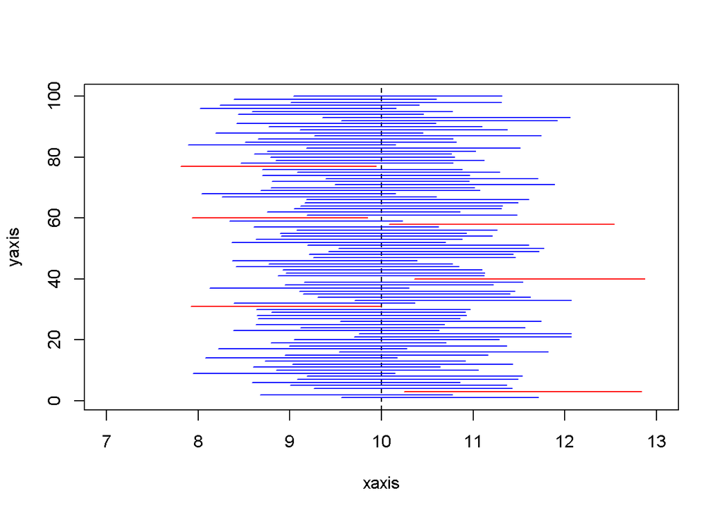

```
## integer(0)
```

```r
#Forth Part ----
#plot the 100 first CI with the average in the middle

xaxis<-seq(mu-3,mu+3,length=100)
yaxis<-1:100

plot(xaxis, yaxis, type = "n") +
      abline(v = 10, lty = 2) +
      for (i in 1:length(xaxis)) {
            lines(c(x.mat[i, 1], x.mat[i, 2]),
                  c(i, i),
                  col = if (x.mat[i, 1] < 10 & x.mat[i, 2] > 10) {
                        "blue"
                  } else{
                        "red"
                  })



      }
```

```r
dev.off()
```